# Classifier for Rotten Tomatoes

## Introduction to the assignment

In this assignment, I'll be analyzing movie reviews in an attempt to determine whether movies are good or bad. I've downloaded a large number of movie reviews from the [Rotten Tomatoes](http://www.rottentomatoes.com) website. Also fetched is a file "movies.dat" that contains metadata for ~65,000 different movies

If you've never seen Rotten Tomatoes before, go spend a few minutes familiarizing yourself with the website. It's a meta-review website that aggregates movie reviews from a large number of critics. Here's what the page for this year's likely [Oscar winner](http://www.rottentomatoes.com/m/the_revenant_2015/) looks like. Note in particular the section on "Critic Reviews" at the bottom -- that's the content that has been scraped and put in the reviews.csv file. Also note that each movie is given a quantitative score on the Tomatometer which is used to classify the movie as either Fresh (good) or Rotten (bad).

The mission is to develop a classifier to determine whether a movie is Fresh or Rotten based on the contents of the reviews given to the movie. As usual, we'll start out with some exploratory data analysis.

#### Author - Rohan Manoj Thakkar

```python
%matplotlib inline
import pandas as pd
import numpy as np
import matplotlib.pyplot as plt

import sklearn
from  sklearn.cross_validation import cross_val_score
from sklearn.cross_validation import train_test_split
from sklearn.naive_bayes import MultinomialNB
from sklearn.feature_extraction.text import CountVectorizer
import statsmodels.formula.api as smf
from sklearn.metrics import mean_squared_error
from sklearn.preprocessing import StandardScaler
from sklearn.decomposition import PCA
```

## Part 1: Descriptive analysis

Before beginning the "real" work, dig into the data a bit do see what you're dealing with. Begin by loading the datasets and dropping rows that have missing data:

```python
reviews = pd.read_csv('reviews.csv')
movies = pd.read_csv("movies.dat", delimiter='\t')
reviews = reviews[~reviews.quote.isnull()]
reviews = reviews[reviews.fresh != 'none']
reviews = reviews[reviews.quote.str.len() > 0]
```

### 1.1: Basic features of the dataset

Answer the following questions by having your python code directly print the answers:

- How many unique reviews (quotes) are in the `reviews` dataset?
- How many unique reviewers (critics) are in the `reviews` dataset?
- How many unique movies are in the `reviews` dataset?
- How many unique movies are in the *`movies`* dataset?
- How many different publications have reviews in the `reviews` dataset?

```python
print "There are %i unique reviews (quotes) in the reviews dataset." % len(reviews.quote.unique())

print "There are %i unique reviews (critics) in the reviews dataset." % len(reviews.critic.unique())

print "There are %i unique movies in the reviews dataset." % len(reviews.title.unique())

print "There are %i unique movies in the movies dataset." % len(movies.title.unique())

print "There are %i different publications have reviews in the reviews dataset." % len(reviews.publication.unique())
```

```
There are 12814 unique reviews (quotes) in the reviews dataset.
There are 541 unique reviews (critics) in the reviews dataset.
There are 1720 unique movies in the reviews dataset.
There are 9405 unique movies in the movies dataset.
There are 64 different publications have reviews in the reviews dataset.
```

### 1.2 Number of reviews per reviewer

Using the `reviews` dataset, create a histogram showing the distribution of the number of reviews per reviewer. Create the bin width (x-axis) to be 1 unit wide, and the range of the axis to be from 0 to 30. Scale the y-axis to show the logarithm of (count of) the number of reviews. Label your axes and make your histogram look professional.

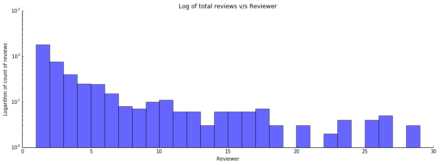

```python
# Spreading the plot to wider extent
plt.figure(figsize=(15,5))

# Creating a subplot of matplotlib to incorporate required modifications
ax = plt.subplot(111)

# Hiding the right and top axes
ax.spines['right'].set_visible(False)
ax.spines['top'].set_visible(False)

# Only show ticks on the left and bottom spines
ax.yaxis.set_ticks_position('left')
ax.xaxis.set_ticks_position('bottom')


# Grouping by critic
d = pd.groupby(reviews, by = reviews.critic)

# Counting the ones which are non-zero
d = d.agg(np.count_nonzero)

# Histogram with bin width=1 and range = (0,30)
plot = ax.hist(d.title, bins=np.arange(0, 30, 1), color = 'blue', alpha = 0.6)

# Calculating Y-axis as log of total number of reviews
plt.yscale('log', nonposy='clip')

# Labeling the graph
plt.xlabel("Reviewer")
plt.ylabel("Logarithm of count of reviews")
plt.title("Log of total reviews v/s Reviewer")

plt.show()
```

### 1.3 Zoom in on a few reviewers

Find the 30 critics with the most reviews, and list their names in a table along with (a) the name of the publication they work for, (b) the date of their first review, and (c) the date of their last review

*hint: use the groupby function to do this quickly*

```python
## Sorting in descending order by number of reviews
e = d.sort(['title'],ascending = [False])

## Index is the name of critic
index = e.index[xrange(30)]

## To find first date
f = pd.groupby(reviews, by = reviews.critic).agg(np.min)

## To find last date
g = pd.groupby(reviews, by = reviews.critic).agg(np.max)

## To find number of reviews
h = pd.groupby(reviews, by = reviews.critic).count()

first= []
last = []
pub = []
total = []
for i in index:
    first.append(f.review_date[f.index == i])
    last.append(g.review_date[g.index == i])
    # max since 'Roger Ebert' worked for more than 1 publication in his career
    pub.append(reviews.publication[reviews.critic==i].max())
    total.append(h.title[h.index==i])

## Clubbing the columns
final = np.column_stack((index,pub,first, last,total))

## To data frame
yolo = pd.DataFrame(final)

# Renaming columns
yolo.columns=['critic','pub','first','last','count']

# Displaying resultant data frame
yolo
```

|  | critic | pub | first | last | count |
| --- | --- | --- | --- | --- | --- |
| 0 | Roger Ebert | Chicago Sun-Times | 2000-01-01 00:00:00 | 2013-06-11 00:00:00 | 1150 |
| 1 | James Berardinelli | ReelViews | 1800-01-01 00:00:00 | 2012-02-07 00:00:00 | 833 |
| 2 | Janet Maslin | New York Times | 2000-01-01 00:00:00 | 2010-09-07 00:00:00 | 526 |
| 3 | Variety Staff | Variety | 2001-02-13 00:00:00 | 2012-08-15 00:00:00 | 449 |
| 4 | Jonathan Rosenbaum | Chicago Reader | 1988-07-11 00:00:00 | 2013-10-22 00:00:00 | 420 |
| 5 | Desson Thomson | Washington Post | 2000-01-01 00:00:00 | 2012-10-08 00:00:00 | 373 |
| 6 | Geoff Andrew | Time Out | 2005-08-11 00:00:00 | 2012-04-05 00:00:00 | 361 |
| 7 | Dave Kehr | New York Daily News | 2000-01-01 00:00:00 | 2013-11-20 00:00:00 | 360 |
| 8 | Kenneth Turan | Los Angeles Times | 2000-01-01 00:00:00 | 2013-10-05 00:00:00 | 282 |
| 9 | Mick LaSalle | San Francisco Chronicle | 2000-01-01 00:00:00 | 2009-11-25 00:00:00 | 280 |
| 10 | Owen Gleiberman | Entertainment Weekly | 1800-01-01 00:00:00 | 2011-09-07 00:00:00 | 241 |
| 11 | Rita Kempley | Washington Post | 2000-01-01 00:00:00 | 2013-11-02 00:00:00 | 236 |
| 12 | Joe Baltake | Sacramento Bee | 2000-01-01 00:00:00 | 2013-08-04 00:00:00 | 231 |
| 13 | Todd McCarthy | Variety | 2000-01-01 00:00:00 | 2012-10-09 00:00:00 | 223 |
| 14 | Vincent Canby | New York Times | 2000-01-01 00:00:00 | 2013-07-29 00:00:00 | 207 |
| 15 | Hal Hinson | Washington Post | 2000-01-01 00:00:00 | 2013-06-26 00:00:00 | 174 |
| 16 | Susan Stark | Detroit News | 2000-01-01 00:00:00 | 2002-10-25 00:00:00 | 167 |
| 17 | Stephen Holden | New York Times | 2000-01-01 00:00:00 | 2009-02-06 00:00:00 | 166 |
| 18 | Derek Adams | Time Out | 2006-01-26 00:00:00 | 2009-10-04 00:00:00 | 154 |
| 19 | Kevin Thomas | Los Angeles Times | 2000-01-01 00:00:00 | 2013-11-02 00:00:00 | 145 |
| 20 | Peter Stack | San Francisco Chronicle | 2000-01-01 00:00:00 | 2002-06-18 00:00:00 | 138 |
| 21 | Bosley Crowther | New York Times | 2000-01-01 00:00:00 | 2008-05-06 00:00:00 | 137 |
| 22 | Rick Groen | Globe and Mail | 2002-03-19 00:00:00 | 2009-08-14 00:00:00 | 129 |
| 23 | Edward Guthmann | San Francisco Chronicle | 2000-01-01 00:00:00 | 2003-04-04 00:00:00 | 121 |
| 24 | Lisa Schwarzbaum | Entertainment Weekly | 1979-01-01 00:00:00 | 2012-08-15 00:00:00 | 117 |
| 25 | Liam Lacey | Globe and Mail | 2001-08-24 00:00:00 | 2012-04-04 00:00:00 | 111 |
| 26 | Emanuel Levy | Variety | 2000-01-01 00:00:00 | 2010-08-06 00:00:00 | 110 |
| 27 | Richard Schickel | The Atlantic | 2000-01-01 00:00:00 | 2013-08-05 00:00:00 | 106 |
| 28 | Richard Corliss | TIME Magazine | 2003-12-16 00:00:00 | 2013-11-06 00:00:00 | 104 |
| 29 | Michael Wilmington | Los Angeles Times | 2000-01-01 00:00:00 | 2013-11-21 00:00:00 | 103 |

### 1.4 Ratings over time

Using the `movies` dataset, create a plot that shows how the average rating per movie (rtAllCriticsRating) has evolved over time. Do this by creating a scatterplot where the x-axis is the year in which the movie was released and the y-axis is rtAllCriticsRating. Drop movies with 0 or unknown values to avoid biasing your results. Then, create a scatterplot that has one point for each remaining movie, and pick an appropriate size/color/transparency for these points to ensure that the graph looks professional. In other words, do not simply use the default settings, as this will produce a dense mess of dots that will be hard to interpret. Finally, overlay on this scatterplot a line graph in orange showing how the average movie rating (the average of rtAllCriticsRating across all movies in a year) has changed over time. Do you notice a trend? What do you think it means?

```python
# Converting rtAllCriticsRating from object to numeric
ratings = movies.rtAllCriticsRating.convert_objects(convert_numeric=True)

# Deleting column with object data type
del movies['rtAllCriticsRating']


# Adding column with same values but in numeric form
movies['rtAllCriticsRating'] = ratings
```

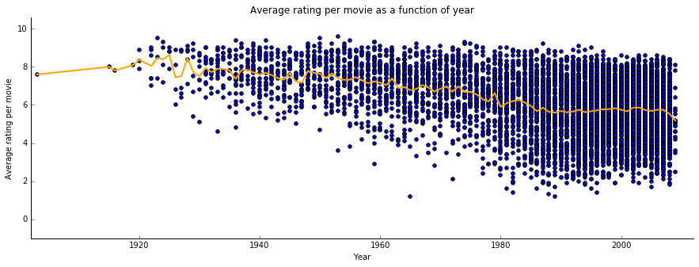

```python
# Widening graph width
plt.figure(figsize=(15,5))

# Creating a subplot of matplotlib to incorporate required modifications
ax = plt.subplot(111)

# Hiding the right and top axes
ax.spines['right'].set_visible(False)
ax.spines['top'].set_visible(False)

# Only show ticks on the left and bottom spines
ax.yaxis.set_ticks_position('left')
ax.xaxis.set_ticks_position('bottom')

# Filtering for positive ratings and plotting scatterplot
plt.scatter(movies.year[movies.rtAllCriticsRating>0], movies.rtAllCriticsRating[movies.rtAllCriticsRating>0])

# Adjusting scale of Y-axis
plt.ylim([movies.rtAllCriticsRating.min()-1,movies.rtAllCriticsRating.max()+1])
# Adjusting scale of X-axis
plt.xlim([movies.year.min()-1,movies.year.max()+1])

# Grouping by movies on filter of positive critics
tp = pd.DataFrame.groupby(movies[movies.rtAllCriticsRating>0], by = movies[movies.rtAllCriticsRating>0].year).mean()


# Plotting line graph to show average critic rating per year
plt.plot(tp.index, tp.rtAllCriticsRating, 'orange',  linewidth = 2)

plt.xlabel("Year")
plt.ylabel("Average rating per movie")
plt.title("Average rating per movie as a function of year")

plt.show()
```

By looking at the above graph, we understand that in general, the average rating per movie decreases with time because the line tends to go downward as the value in X-axis rises.

This means, that on an average, the critics started being more strict in their ratings on a movie and with the number of movies increasing with time, the percentage of good movies in a year starts to decrease with these additional movies that do not manage to impress the critics.

## Part 2: Naive Bayes

Now it gets fun! You are going to use a [Naive Bayes classifier](https://en.wikipedia.org/wiki/Naive_Bayes_classifier) to build a prediction model for whether a review is fresh or rotten, depending on the text of the review. Review the assigned readings on Canvas, as well as the relevant lecture notes before embarking on this journey.

### Using CountVectorizer

One thing that may help you in the following problems is the [CountVectorizer](http://scikit-learn.org/stable/modules/generated/sklearn.feature_extraction.text.CountVectorizer.html) object in Scikit-learn. This will help you convert your raw text fields into "bag of words" vectors, i.e. a data structure that tells you how many times a particular word appears in a blurb. Here's a simple example, make sure you understand what's going on!

```python
from sklearn.feature_extraction.text import CountVectorizer

text = ['machine learning rocks', 'machine learning rules', 'rocks rocks rules']
print "Original text is\n", '\n'.join(text)

vectorizer = CountVectorizer(min_df=0)

# call `fit` to build the vocabulary
vectorizer.fit(text)

# call `transform` to convert text to a bag of words
x = vectorizer.transform(text)

# CountVectorizer uses a sparse array to save memory, but it's easier in this assignment to
# convert back to a "normal" numpy array
x = x.toarray()

print
print "Transformed text vector is \n", x

# `get_feature_names` tracks which word is associated with each column of the transformed x
print
print "Words for each feature:"
print vectorizer.get_feature_names()
```

```
Original text is
machine learning rocks
machine learning rules
rocks rocks rules

Transformed text vector is
[[1 1 1 0]
 [1 1 0 1]
 [0 0 2 1]]

Words for each feature:
[u'learning', u'machine', u'rocks', u'rules']
```

### 2.1 Create your X input and Y output

Using the `reviews` dataframe, compute a pair of numerical X, Y arrays where:

- X is a `(nreview, nwords)` array. Each row corresponds to a bag-of-words representation for a single review. This will be the *input* to your model.
- Y is a `nreview`-element 1/0 array, encoding whether a review is Fresh (1) or Rotten (0). This is the desired *output* from your model.

Make sure to remove items with no review text

```python
def make_xy(reviews, vectorizer=None):
    temp = reviews.quote
    # Create new only if vectorizer is none
    if vectorizer is None:
        vectorizer = CountVectorizer(min_df=0)

    X = vectorizer.fit_transform(temp)
    Y = (reviews.fresh=='fresh').values.astype(np.int)
    return X, Y
```

```python
X, Y = make_xy(reviews)
```

### 2.2 Test-Train split

Next, randomly split the data into two groups: a training set and a validation set. You can do this manually, as you did in the prior problem set. Or, use [`train_test_split`](http://scikit-learn.org/stable/modules/generated/sklearn.cross_validation.train_test_split.html) to do this auto-magically. See [this guide](http://scikit-learn.org/stable/modules/cross_validation.html) for a simple example of how `train_test_split` works.

```python
train_X, test_X,train_Y, test_Y = sklearn.cross_validation.train_test_split(X,Y)
```

### 2.3 Naive Bayes with `MultinomialNB`

Use the training set to train a Naive Bayes classifier using the [`MultinomialNB`](http://scikit-learn.org/stable/modules/generated/sklearn.naive_bayes.MultinomialNB.html) object. Report the accuracy of this model on both the training and testing data. What do you observe? Interpret these results!

*Hint: This shouldn't take more than 5-10 lines of code to accomplish*

```python
fitted_model = sklearn.naive_bayes.MultinomialNB()

fitted_model.fit(train_X,train_Y)

print 'Performance of training set is =',(1-(abs(fitted_model.predict(train_X)-train_Y).sum())/float(len(train_Y)))*100,'%'

print 'Performance of test set is =',(1-(abs(fitted_model.predict(test_X)-test_Y).sum())/float(len(test_Y)))*100,'%'
```

```
Performance of training set is = 92.2992845787 %
Performance of test set is = 77.8539493294 %
```

Thus, we see that the accuracy of the Naive Bayes model implemented is great for the training data and average for the test data which means that training set achieves better performance as expected because the model is fit on that data and the test data has a decent performance too.

## Part 3: Evaluation

### 3.1 Estimate the likelihood of your data

Given a fitted model, you can compute the log-likelihood of your data as a way to assess the performance of your model. Using `fitted_model.predict_logproba`, the idea is to write a function that computes the log-likelihood of a dataset, so that we can inspect the log-likelihood of your training and testing data given your fitted model from part 2.

To help you out a little bit, we'll do this part for you. But make sure you understand it, because you'll need to use this later!

```python
def log_likelihood(model, x, y):
    prob = model.predict_log_proba(x)
    rotten = y == 0
    fresh = ~rotten
    return prob[rotten, 0].sum() + prob[fresh, 1].sum()

# output the likelihood of your test data (example - you may need to
# chance the nambes of the variables below to match your code in 2.2 and 2.3
# the function becomes z2 or whatever which is after the fit
print 'Log likelihood of train is =',log_likelihood(fitted_model, train_X, train_Y)
print 'Log likelihood of test is =',log_likelihood(fitted_model, test_X, test_Y)
```

```
Log likelihood of train is = -1884.1612637
Log likelihood of test is = -1933.3421401
```

### 3.2 Cross-Validation

Why do we care about the log-likelihood of our data? You guessed it: Cross-Validation.

Our classifier has a few hyperparameters. The two most important are:

1. The `min_df` keyword in `CountVectorizer`, which will ignore words which appear in fewer than `min_df` fraction of reviews. Words that appear only once or twice can lead to overfitting, since words which occur only a few times might correlate very well with Fresh/Rotten reviews by chance in the training dataset.
2. The [`alpha` keyword](http://scikit-learn.org/stable/modules/naive_bayes.html#multinomial-naive-bayes) in the Bayesian classifier is a "smoothing parameter" -- increasing the value decreases the sensitivity to any single feature, and tends to pull prediction probabilities closer to 50%.

How are we are going to use cross-validation to tune these hyperparameters? The objective function we want to maximize is the log-likelihood of our data. Fill in the remaining code in this block, to loop over many values of `alpha` and `min_df` to determine which settings are "best" in the sense of maximizing the cross-validated log-likelihood.

*hint: sklearn has a built-in function, `sklearn.cross_validation.cross_val_score`, that might save you a lot of time here...*

```python
#the grid of parameters to search over
alphas = [0, .1, 1, 5, 10, 50]
min_dfs = [1e-5, 1e-4, 1e-3, 1e-2, 1e-1]


#Find the best value for alpha and min_df, and the best classifier
best_alpha = None
best_min_df = None
max_loglike = -np.inf


for alpha in alphas:
    for min_df in min_dfs:
        vectorizer = CountVectorizer(min_df = min_df)
        ## Finding input and output
        X, Y = make_xy(reviews, vectorizer)
        ## Fitting model on the same
        model = sklearn.naive_bayes.MultinomialNB(alpha=alpha).fit(X,Y)
        ## Calculating loglike score
        score = sklearn.cross_validation.cross_val_score(model, X,Y,cv=5, scoring=log_likelihood).mean()
        ## if higher value for loglike, update best_min_df and best_alpha
        if score>max_loglike:
            max_loglike = score
            best_alpha = alpha
            best_min_df = min_df
```

### 3.3 Putting it together

Now that you've determined values for alpha and min_df that optimize the cross-validated log-likelihood, repeat the steps in 2.1-2.3 to train a final classifier with these parameters and re-evaluate the accuracy. Discuss the various ways in which Cross-Validation has affected the model. Is the new model more or less accurate? Is overfitting better or worse?

```python
## Using given value for min_df while building input and output
def make_xy_1(reviews, min_df, vectorizer=None):
    temp = reviews.quote
    ## Using the input value of min_df
    if vectorizer is None:
        vectorizer = CountVectorizer(min_df=min_df)

    X = vectorizer.fit_transform(temp)
    Y = (reviews.fresh=='fresh').values.astype(np.int)
    ## Stores all words in 'names' array for further use
    names = np.array(vectorizer.get_feature_names())
    return X, Y,names
```

```python
X_1,Y_1, names = make_xy_1(reviews,best_min_df)

train_X_1, test_X_1,train_Y_1, test_Y_1 = sklearn.cross_validation.train_test_split(X_1,Y_1)
```

```python
fitted_model_1 = sklearn.naive_bayes.MultinomialNB(alpha=best_alpha)

fitted_model_1.fit(train_X_1,train_Y_1)

print 'Performance of training set is =',(1-(abs(fitted_model_1.predict(train_X_1)-train_Y_1).sum())/float(len(train_Y_1)))*100,'%'

print 'Performance of test set is =',(1-(abs(fitted_model_1.predict(test_X_1)-test_Y_1).sum())/float(len(test_Y_1)))*100,'%'
```

```
Performance of training set is = 78.8155802862 %
Performance of test set is = 75.0819672131 %
```

```python
print log_likelihood(fitted_model_1, train_X_1, train_Y_1)
print log_likelihood(fitted_model_1, test_X_1, test_Y_1)
```

```
-4485.88517744
-1738.46727522
```

### 3.4 Other way round?

What happens if you tried this again using a function besides the log-likelihood -- for example, the classification accuracy? Interpret these results

```python
def measure_score(model,x,y):
    return model.score(x,y)
```

```python
#Find the best value for alpha and min_df, and the best classifier
best_alpha_1 = None
best_min_df_1 = None
max_score = -np.inf


for alpha_1 in alphas:
    for min_df_1 in min_dfs:
        vectorizer_1 = CountVectorizer(min_df = min_df_1)
        X, Y = make_xy(reviews, vectorizer_1)
        model = sklearn.naive_bayes.MultinomialNB(alpha=alpha_1).fit(X,Y)
        score = sklearn.cross_validation.cross_val_score(model, X,Y,cv=5, scoring=measure_score).mean()
        if score>max_score:
            max_score = score
            best_alpha_1 = alpha
            best_min_df_1 = min_df_1
```

```python
# Using new value of min_df
X_2,Y_2, names_1 = make_xy_1(reviews,best_min_df_1)

# Re-splitting into train and test accordingly
train_X_2, test_X_2,train_Y_2, test_Y_2 = sklearn.cross_validation.train_test_split(X_2,Y_2)

## New NB model
fitted_model_2 = sklearn.naive_bayes.MultinomialNB(alpha=best_alpha_1)

## fitting the model
fitted_model_2.fit(train_X_2,train_Y_2)

print 'Performance of training set is =',(1-(abs(fitted_model_2.predict(train_X_2)-train_Y_2).sum())/float(len(train_Y_2)))*100,'%'

print 'Performance of test set is =',(1-(abs(fitted_model_2.predict(test_X_2)-test_Y_2).sum())/float(len(test_Y_2)))*100,'%'
```

```
Performance of training set is = 62.8875198728 %
Performance of test set is = 61.5499254844 %
```

### 3.5 Interpretation

What words best predict a fresh or rotten review? Using your classifier and the `vectorizer.get_feature_names` method, determine which words best predict a positive or negative review. Print the 10 words that best predict a "fresh" review, and the 10 words that best predict a "rotten" review. For each word, what is the model's probability of freshness if the word appears one time?

#### Hints

- In thinking about how to measure the impact of a word on freshness rating, consider computing the classification probability for a feature vector which consists of all 0s, except for a single 1. What does this probability refer to?
- `numpy.identity` generates an identity matrix, where all values are zero except the diagonal elements which have a value of one

```python
from pandas import DataFrame

## Identity matrix
id_matrix = np.identity(test_X_1.shape[1])

## Probability of freshness will be 1st column of p
p = fitted_model_1.predict_proba(id_matrix)[:,0]

# Sorting in ascending order
index = np.argsort(p)

# First 10 = fresh
fresh_words = names[index[:10]]

# Last 10 = bottom
rotten_words = names[index[-10:]]


# Respective probabilties of fresh
fresh_prob = p[index[:10]]

# Respective probabilties of rotten
rotten_prob = p[index[-10:]]

## Fresh data frame
fresh = {'word':fresh_words, 'probability':fresh_prob}
fresh = DataFrame(data = fresh)


## Rotten data frame
rotten = {'word':rotten_words, 'probability':rotten_prob}
rotten = DataFrame(data = rotten)

print 'Positive review -'
print fresh
print
print 'Negative review-'
print rotten
```

```
Positive review -
   probability           word
0     0.104114    masterpiece
1     0.111695           rare
2     0.114701        delight
3     0.121858          gives
4     0.125732         moving
5     0.134555     remarkable
6     0.137778       touching
7     0.141158       funniest
8     0.141474  entertainment
9     0.141474    intelligent

Negative review-
   probability            word
0     0.775359           sadly
1     0.776562       formulaic
2     0.778539  disappointment
3     0.781352            dull
4     0.786108         unfunny
5     0.798874           bland
6     0.808376      uninspired
7     0.821494       pointless
8     0.838117            lame
9     0.861725   unfortunately
```

Thus, we find the top 10 words that occur in positive and negative reviews based on the classification probability for a feature vector which consists of all 0s, except for a single 1 because it uses an identity matrix for calculating this which has only 1 in each row and all others 0s.

### 3.6 Error Analysis

One of the best sources for inspiration when trying to improve a model is to look at examples where the model performs poorly. Find 5 fresh and rotten reviews where your model performs particularly poorly. Print each review.

What do you notice about these mis-predictions? Naive Bayes classifiers assume that every word affects the probability independently of other words. In what way is this a bad assumption? In your answer, report your classifier's Freshness probability for the review "This movie is not remarkable, touching, or superb in any way".

```python
# Predicting probabilties on earlier variables (before extra credit)
prob = fitted_model_1.predict_proba(X_1)[:, 0]

# Predicting based on model
predict = fitted_model_1.predict(X_1)

## Top 5 rows on sorting are fresh but wrongly predicted as rotten
poor_rotten = np.argsort(prob[Y_1 == 0])[:5]

## Top 5 rows on sorting are rotten but wrongly predicted as fresh
poor_fresh = np.argsort(prob[Y_1 == 1])[-5:]

print "Mismatched quotes in rotten category:"
print
count = 0;

for row in poor_rotten:
    count += 1
    print str(count) + ". " + reviews[Y_1 == 0].quote.irow(row)
    print

print
print "Mismatched quotes in fresh category:"
print
count = 0;
for row in poor_fresh:
    count += 1
    print str(count) + ". " + reviews[Y_1 == 1].quote.irow(row)
    print
```

```
Mismatched quotes in rotten category:

1. It survives today only as an unusually pure example of a typical 50s art-film strategy: the attempt to make the most modern and most popular of art forms acceptable to the intelligentsia by forcing it into an arcane, antique mold.

2. It's a sad day when an actor who's totally, beautifully in touch with his dark side finds himself stuck in a movie that's scared of its own shadow.

3. The Disney organization is worst when it makes "family entertainment" and best when it sticks to pure, simple, charming fantasy.

4. Walken is one of the few undeniably charismatic male villains of recent years; he can generate a snakelike charm that makes his worst characters the most memorable, and here he operates on pure style.

5. The Waterboy is arguably Sandler's most enjoyable motion picture to date, but it's still far from a masterpiece.


Mismatched quotes in fresh category:

1. Dead Man Walking could easily be manipulative or exploitative, but it's neither. Instead, this is hard-hitting drama that neither accepts nor offers quarter.

2. Might it be a serious attempt to right some unretrievable wrong via gallows humor which avoids the polemics? This seems to be the course taken; the attempt at least can be respected in theory.

3. There's too much talent and too strong a story to mess it up. There was potential for more here, but this incarnation is nothing to be ashamed of, and some of the actors answer the bell.

4. Though it's a good half hour too long, this overblown 1993 spin-off of the 60s TV show otherwise adds up to a pretty good suspense thriller.

5. Some of the gags don't work, but fewer than in any previous Brooks film that I've seen, and when the jokes are meant to be bad, they are riotously poor. What more can one ask of Mel Brooks?
```

Thus,we see that the assumption made by Naive Bayes that every word affects the probability independently of other words is a bad one because the meaning of word is contextual. For example, two negatives in the same context mean a positive and it is inaccurate to consider a review as negative in such cases.

```python
# Taking input string
string_in = 'This movie is not remarkable, touching, or superb in any way'

# Converting to series to apply function
string = pd.Series(string_in)


# Using earlier value of best_min_df for vectorizer
vectorizer = CountVectorizer(min_df=best_min_df)

## Fitting dictionary
vectorizer.fit(reviews.quote)

# New X array of 1 row by input string
x_new = vectorizer.transform(string)

# Probability of freshness
print 'Freshness probability of the string "',string_in,'" is',float(fitted_model_1.predict_proba(x_new)[:,0])
```

[output not shown]

## Part 4: Principal Component Analysis

Just when you thought you were *finally* done with the [Boston Housing Prices Data Set](http://archive.ics.uci.edu/ml/datasets/Housing), it has come back to haunt you for a few more minutes. Make sure you're up and running as you were on the previous problem set:

```python
from sklearn.decomposition import PCA
from sklearn.datasets import load_boston
bdata = load_boston()

# Creating a final 2-dimensional array consisiting of total 14 columns - 13 indicator variables and target values
data = np.insert(bdata.data, bdata.data.shape[1], bdata.target, axis = 1)

# Function to standardize data
def standardize(raw_data):
    return ((raw_data - np.mean(raw_data, axis = 0)) / np.std(raw_data, axis = 0))

## Standardizing data
data = standardize(data)
```

# 4. Boston dataset

### 4.1 Visualization

Use matplotlib to create a scatter plot that shows the relationship between the median value of the home (y-axis) and the per-capita crime rate (x-axis). Properly label your axes, and make sure that your graphic looks polished and professional. If you didn't get full credit for this on the first problem set, get full credit this time!

Then, just as you did on the previous problem set, use the [Linear Regression class](http://scikit-learn.org/stable/modules/generated/sklearn.linear_model.LinearRegression.html) from sklearn or the [OLS class](http://wiki.scipy.org/Cookbook/OLS) from SciPy to regress median housing price on average number of rooms per house. Use a training set consisting of 66% of your instances to fit your regression model. Report the RMSE on the training and test set.

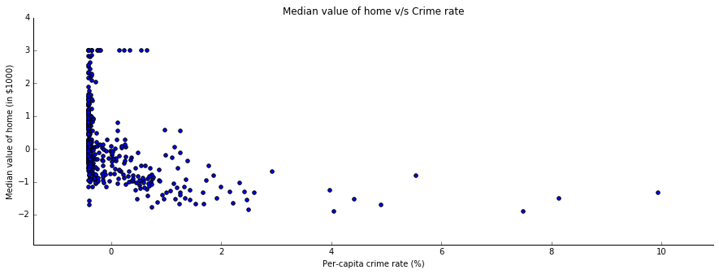

```python
# Spreading the plot to wider extent
plt.figure(figsize=(15,5))

# Plotting a scatterplot with median value of home being Y-axis and per-capita crime rate being X-axis
plt.scatter(data[:,0],data[:,13])

# Creating a subplot of matplotlib to incorporate required modifications
ax = plt.subplot(111)

# Hiding the right and top axes
ax.spines['right'].set_visible(False)
ax.spines['top'].set_visible(False)

# Only show ticks on the left and bottom spines
ax.yaxis.set_ticks_position('left')
ax.xaxis.set_ticks_position('bottom')

# Renaming the X and Y axes and the title of the plot
plt.xlabel("Per-capita crime rate (%)")
plt.ylabel("Median value of home (in $1000)")
plt.title("Median value of home v/s Crime rate")

# Limiting the range of values of X and Y axes to the minimum
plt.xlim([data[:,0].min()-1,data[:,0].max()+1])
plt.ylim([data[:,13].min()-1,data[:,13].max()+1])


# Display the scatterplot
plt.show()
```

```python
# Importing package needed for fitting linear regression
import scipy.stats as stats

# leave the following line untouched, it will help ensure that your "random" split is the same "random" split used by the
#rest of the class
np.random.seed(seed=13579)

# Defining a splitting function that takes as input the given array and percentage of split
def split(data, per_train):
    # Shuffled the input data randomly, based on the seed above
    np.random.shuffle(data)
    # Inserts the top train% rows (66 in this case) to the 'train' array
    train = data[0:per_train*len(data),:]
    # Inserts the bottom (1--0train)5 rows to the 'test' array
    test = data[per_train*len(data):len(data),:]
    # Return the resultant arrays
    return train, test

# Splitting the overall data to 66% in training and 34% in test and storing the resultants in bdata_train and bdata_test
bdata_train, bdata_test = split(data, 0.66)
```

```python
from math import sqrt

# Extracting the parameters of fitted linear regression
slope_2, intercept_2, r_value_2, p_value_2, std_err_2 = stats.linregress(bdata_train[:,5],bdata_train[:,13])

# Writing the equation of the training
y_train = slope_2*bdata_train[:,5]+intercept_2

# Writing the equation of the test
y_test = slope_2*bdata_test[:,5]+intercept_2

## RMSE for training
print 'RMSE of training data is =', sqrt(mean_squared_error(bdata_train[:,13],y_train))

## RMSE for test
print 'RMSE of test data is =',sqrt(mean_squared_error(bdata_test[:,13],y_test))
```

```
RMSE of training data is = 0.689134017461
RMSE of test data is = 0.781462649295
```

### 4.2 So many scatterplots!

Choose 8 out of the 14 features of the housing data that you think are most interesting to study. Create an 8x8 grid of scatterplots showing how each of these variables relate to each other. You want to produce something that looks generally like [this image](http://iogas.net/wp-content/gallery/iogas-evaluation/scatterplot-matrix-point-density.png).

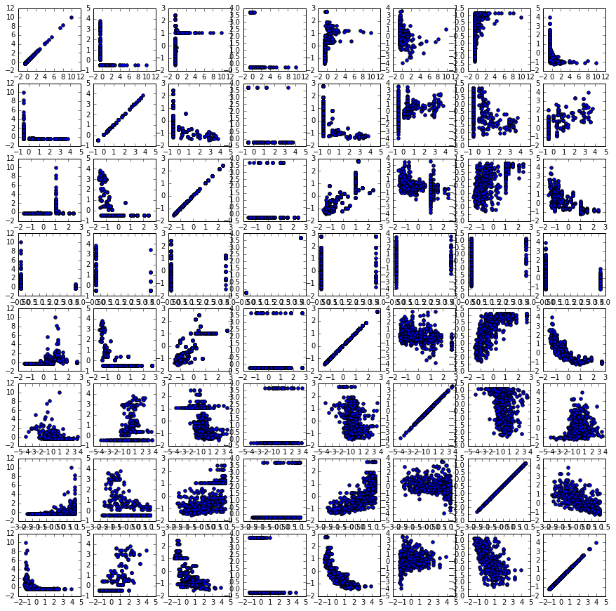

```python
plt.figure(figsize=(15,15))
for i in xrange(8):
    for j in xrange(8):
        plt.subplot(8, 8, i * 8 + j + 1)
        # Scatter plot on ith column and jth column of data array
        plt.scatter(data[:,i],data[:,j])
```

### 4.3 PCA to the rescue

Run principal component analysis using [PCA](http://scikit-learn.org/stable/modules/generated/sklearn.decomposition.PCA.html) from sklearn to find the first 12 principal components of your data. Use only your training set (66% of the data), and use all features *except* the median housing price. Create a figure showing how the amount of variance explained by your components increases as you increase the number of components from 1 to 12.

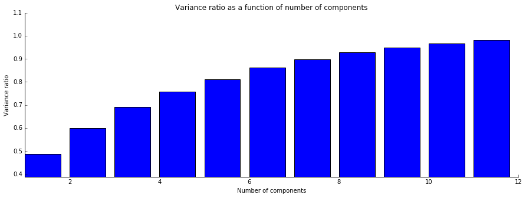

```python
plt.figure(figsize=(15,5))

# Creating a subplot of matplotlib to incorporate required modifications
ax = plt.subplot(111)

# Hiding the right and top axes
ax.spines['right'].set_visible(False)
ax.spines['top'].set_visible(False)

# Only show ticks on the left and bottom spines
ax.yaxis.set_ticks_position('left')
ax.xaxis.set_ticks_position('bottom')

#3 Training PCA model
pca = sklearn.decomposition.PCA(n_components=12)
## all features except the housing price
pca.fit(bdata_train[:,range(13)])
result = pca.explained_variance_ratio_

# Temporary sum of variance ratio
sum = 0

# To use in graph
Y_axis = []
for i in result:
    # Adding new variance ratio to temp sum and inserting the same in Y-axis
    sum+=i
    Y_axis.append(sum)

# No of components
X_axis = [1,2,3,4,5,6,7,8,9,10,11,12]

# Bar graph
plt.bar(X_axis, Y_axis)

# To better visualize the increase in variance ratios as no of components increase
plt.ylim([Y_axis[0]-0.1,1.1])
plt.xlim([1,12])

# Labeling graph
plt.xlabel("Number of components")
plt.ylabel("Variance ratio")
plt.title("Variance ratio as a function of number of components")

plt.show()
```

### 4.4 Visualizing the components

Create a 1X3 grid containing three scatter plots of your training data:

1. PCA 1 vs. PCA 2 (you will need to use `fit_transform` to project your training data onto these two components)
2. PCA 1 (x-axis) vs. median housing value
3. PCA 2 vs. median housing value

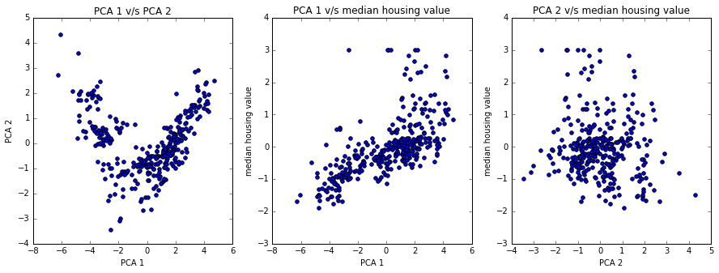

```python
pca1 = sklearn.decomposition.PCA(n_components=12)

array = pca1.fit_transform(bdata_train[:,range(13)])

plt.figure(figsize=(15,5))

## PCA 1 v/s PCA 2
plt.subplot(1, 3, 1)
plt.scatter(array[:,0],array[:,1])
plt.title("PCA 1 v/s PCA 2")
plt.xlabel("PCA 1")
plt.ylabel("PCA 2")

## PCA 1 v/s median housing value
plt.subplot(1, 3, 2)
plt.scatter(array[:,0],bdata_train[:,13])
plt.title("PCA 1 v/s median housing value")
plt.xlabel("PCA 1")
plt.ylabel("median housing value")

## PCA 2 v/s median housing value
plt.subplot(1, 3, 3)
plt.scatter(array[:,1],bdata_train[:,13])
plt.title("PCA 2 v/s median housing value")
plt.xlabel("PCA 2")
plt.ylabel("median housing value")
```

### 4.5 Regression and PCA

Using just the first Principal Component learned on the training data, project all of your data (including the test data) onto this 1-dimensional subspace using the `fit_transform` function. Now, using your training data, fit a regression of median housing price on this first principal component of your data. Report the RMSE of this regression for both the training and test set. How do these results compare to your results from 4.1? Interpret your results!

```python
## PCA on housing prices of training data
output = pca.fit_transform(bdata_train[:,range(13)])


## PCA on housing prices of test data
output_1 = pca.fit_transform(bdata_test[:,range(13)])

# Extracting the parameters of fitted linear regression
slope_3, intercept_3, r_value_3, p_value_3, std_err_3 = stats.linregress(output[:,0], bdata_train[:,13])

# Writing the equation of the regression line for train
y_train_1 = slope_3*output[:,0]+intercept_2

# Writing the equation of the regression line for test
y_test_1 = slope_3*output_1[:,0]+intercept_2

## RMSE of first predictions for training data
print 'RMSE of training data is =', sqrt(mean_squared_error(bdata_train[:,13],y_train_1))

## RMSE of first predictions for test data
print 'RMSE of test data is =',sqrt(mean_squared_error(bdata_test[:,13],y_test_1))
```

```
RMSE of training data is = 0.714680123986
RMSE of test data is = 1.52698764535
```